# Wrangle Report

#### Chloe Xue June 2019

- Introduction
- Project Introduction
- Dataset Introduction
- Data Wrangling Process
- Part I. Gathering Data
- Part II. Accessing Data
- Data Quality and Tidiness
- Part III. Cleaning Data
- Part IV. Storing Data

### Project Introduction

> In this project, the dataset I analyze is the tweet archive of Twitter user [@dog_rates](https://twitter.com/dog_rates), also known as WeRateDogs. This twitter account rates people's dogs with ratings on denominator of 10 along with comments. This archive contains basic tweet data (tweet ID, timestamp, text, etc.) for all 5000+ of tweets from August 1, 2017.

> The wrangle act is very important to the whole project as it prepares the data before making valuale and insightful analysis. The wrangling steps need to be accurate and careful as it impact the results on final table. Data from raw sources is messy and untide. A Clean dataframe will make clean visualizations and deliver clear information to audience. Every step in wrangling process is essential and critical.

### Dataset Introduction

- Twittwer Archive. Originally the enhanced Twitter archive contains 5000+ tweets with basic tweet data. It is being filtered for tweets with ratings only along with information like dog name, stage, etc.
- Image Prediction. This dataset is created by running every image in the WeRateDogs Twitter Archive through a neural network that can classify top three predictions(corresponding to the most confident predictions) on breeds of dogs alongside each tweet ID, image URL and the image number.
- Retweets and Favorites.Querying from Twitter's API, this dataset generates retweet count and favorite count of each tweet ID in WeRateDogs Twitter Archive.

# Data Wrangling Process

Data Wrangling process includes three steps: Gathering, Accessing and Cleaning.

## Step I: Gathering Data

1. Given twitter archive enhance dataset, read it using pandas read_csv.

```python
archive = pd.read_csv('twitter-archive-enhanced.csv')
```

1. Given Image Prediction dataset internally, download programmatically using the request library.

Use response = requests.get() and the given url, write the tsv file into python. Then use pandas read_csv read it.

```python
image = pd.read_csv('image_predictions.tsv', delimiter = '\t')
```

1. Querying data from Twitter API. And generating retweet count and favorite count for tweets_data dataset.

After applying a developer account and get private API keys from Twitter. Using the information Twitter provides to write JSON data into a txt file. Then extract retweet count and favorite count from txt file and write it into a dataframe: tweets_data. Here is the code using tweepy.API:

```python
api = tweepy.API(auth, wait_on_rate_limit = True,wait_on_rate_limit_notify = True)
```

Above three procedures gathering data will finally generate three dataframes with a shared information: 'tweet_id'. Every tweet_id associates with a tweet of WeRateDogs.

## Step 2: Accessing Data

Data need to be asscessed both visually and programmatically for quality and tidiness.

Before I define the issues on Quality and Tidiness. I display three dataframes to visually assess and programmatically assess. Codes I use in accessing dta: df.info(), df.head(), df.tail(). Methods using for assessing include: value_counts(), isna().value_counts(), isnull().value_counts(), duplicated().value_counts().

Next I define 9 quality issues and 3 tidiness issues.

### Quality:

- archive: Including 181 retweets and 78 replies that are unnessary. (#1)
- archive: 'expanded_url' has missing values. That means it doesn't include an image. The ratings will not be considered without images. (#2)
- archive: 'rating_denominator' column has value not equal to 10. (#3)
- archive: 'rating_numerator' column has unexpected value. (#4)
- archive: Data type for timestamp is not correct. (#5)
- archive: 'source' column is not clean. (#6)
- image: Dog breed names have delimiter that need to be cleaned. Name should be caplitalized. (#8)
- tweets: Data type for retweet_count and favorite_count should be integer. (#9)
- Counts of tweets are inconsistent in three dataset. (#10)

### Tidiness:

- archive: 'doggo','floofer','pupper','puppo' columns refer to four categories of dog stage, that should be under one column: 'dog_stage'. (#7)
- image: Aggregate p1, p2 and p3 to classify each image into dog_type(Dog, Might Dog and Not Dog), dog_breed(with best confidence). (#8)
- tweets: This can be merged to archive data. Three dataset should be merged into one final dataset. (#10)

## Step3: Cleaning Data.

Cleaning data in three procedures: Define, Code and Test.

- #### Clear missing values and duplicates.

```python
archive_clean[archive_clean.retweeted_status_id.isna()]
archive_clean[archive_clean.in_reply_to_status_id.isna()]
archive_clean[archive_clean.expanded_urls.notnull()]
```

- #### Correct datat type for several columns.

```python
archive_clean.timestamp = pd.to_datetime(archive_clean.timestamp)
archive_clean['source'] = pd.Categorical(archive_clean['source'])
archive_clean['source'] = pd.Categorical(archive_clean['source'])
tweets = tweets.astype({"retweet_count": int, "favorite_count": int})
```

- #### Clean 'source' without url information.

```python
archive_clean['source'] = archive_clean['source'].apply(lambda x: re.search('rel="nofollow">(.*)</a>', x).group(1))
```

- #### Clean rating scores.
1. I first check with 'text' to see if there are any obivious mistakes.
2. I change all the rating denominator to 10 to create a clean base.
3. Compute the ratio and re-assign numerator with a denomiator 10.
4. Check if the low ratings with numerator lower than 10 are real.

Here is example of code I assign the rating value:

```python
archive_clean.loc[archive_clean.tweet_id == 695064344191721472, ['rating_numerator','rating_denominator']] = [13,10]
```

- #### Unpivot four dog stage columns into one to make it cleaner. I use pd.melt() function.
1. First I create a subset with none assigned dog stages data.
2. I use pd.melt() to unpivot data with assigned dog stage.
3. Append the two dataframes together and drop duplicates.

Here is the code I use to perform unpivoting.

```python
archive_clean = pd.melt(archive_clean,
             id_vars = ['tweet_id', 'timestamp', 'source', 'text','rating_numerator', 'rating_denominator', 'name'],
             value_vars = ['doggo', 'floofer','pupper', 'puppo'],var_name = 'dog_stage', value_name = 'Bool')
```

- #### Aggreate p1, p2, p3 to one dog breed, creating column to identify if the prediction is dog or not and adding its confidence level.

My approach for classifying predictions:

1. If all top three predictions are 'true' for dog, dog_type is Dog. The breed is p1 prediction with best confidence.
2. If all top three predictions are 'false' for dog, dog_type is Not Dog. The breed is None with p1 confidence.
3. There are mixed 'true' and 'false' predictions. Compare the sum of true confidence and false confidence, identify a threshold that if true confidence is higher than that value, dog_type is Dog. Otherwise, dog_type is Might Dog.

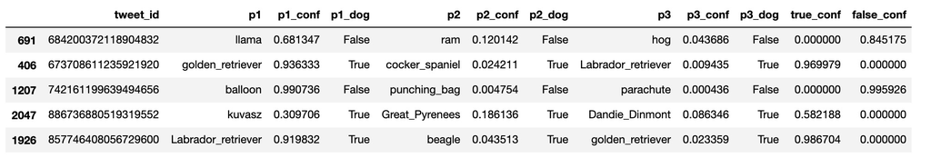

Above is the dataframe after I calculate sum of true confidence and sum of false confidence. Then I create three sub dataframes to identify dog_type and dog_breed.

```python
all_true = image_clean[image_clean.false_conf ==0]
all_false = image_clean[image_clean.true_conf == 0]
mix = image_clean.loc[(image_clean['true_conf'] != 0) & (image_clean['false_conf'] != 0)]
```

Reading from summary statistics of mix, I define a threshold, the 3-rd quantile of false confidence. Predictions with true confidence bigger than the threshold are identified as 'Dog', otherwise predictions are 'Might Dog'.

The image table looks like this after I clean in this step:

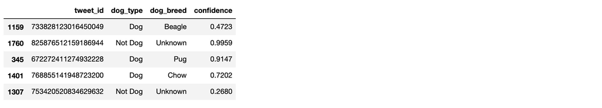

- #### Dog breed names need to be cleaned to remove delimiters and be capitalized.

```python
image_clean['bre'] = image_clean['dog_breed'].astype(str).str.split('-')
image_clean['dog_breed'] = image_clean['bre'].apply(' '.join)
image_clean['dog_breed'] = image_clean['dog_breed'].str.title()
```

- #### Merge three dataframes to one final table. First merge archive and image dataframes, then merge it with tweets. The key is tweet_id. Final length for the table is 2094 as I keep all the valid ratings and image predictions.

```python
s1 = pd.merge(archive_clean,image_clean, on = ['tweet_id','tweet_id'], how = 'left')
ratedogs = pd.merge(s1, tweets, on = 'tweet_id', how = 'left')
```

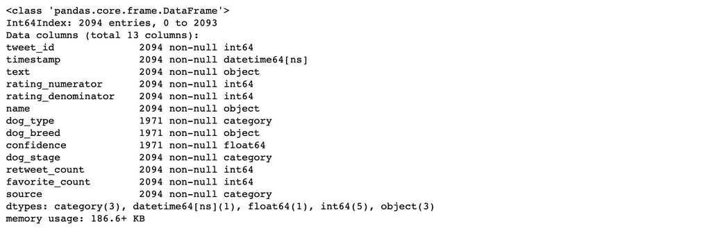

## Part 4: Stroing Data.

Use pandas to_csv to write the dataframe into csv file to further analysis.

```python
ratedogs.to_csv('twitter_archive_master.csv', encoding = 'utf-8', index = False)
```